# S2 traslado de estudiantes

# Importancia

Para nadie es un secreto que la educación pública en nuestro país es totalmente deficiente. La coyuntura actual en la que vivimos debido a la pandemia ha causado que el aprendizaje de estos niños se vea afectado de manera negativa, haciendo que varios de estos dejen los estudios. La pandemia no solo ha afectado el aprendizaje de estos niños, sino que también sus familias se han visto afectadas económicamente, bajando sus ingresos, lo que ocasionó que muchos padres tomaran la decisión de trasladar a sus hijos de un colegio privado a un colegio público para que así puedan continuar con sus estudios.

# Objetivos del proyecto

- Demostrar si la pandemia afectó al sector educativo en los colegios del distrito de Andahuaylas, departamento de Apurímac.
- Encontrar relación entre nuestras variables de interés de acuerdo a cada hipótesis.
- Rechazar o validar las hipótesis planteadas.

# Hipótesis

**Hipótesis 1**: A raíz de la pandemia las familias redujeron sus ingresos, lo que ocasionó que en el caso de los colegios privados se redujera el número de matriculados en el año 2020 a comparación del 2019. Creemos que en el caso de los colegios públicos el número de matriculados en el 2020 aumentó a comparación que en el 2019.

**Hipótesis 2**: Se cree que a raíz de la pandemia el rendimiento académico de los estudiantes disminuyó durante el 2020 causando que haya una menor cantidad de aprobados a comparación del 2019.

**Hipótesis 3**: Cuando los alumnos desertan en sus estudios, esto puede tener mucha relación con el total de matriculados de un colegio al año siguiente, debido a esto el número de matriculados en el 2020 tiene relación con el número de retirados en el 2019.

# ANÁLISIS DESCRIPTIVO

# Muestreo

Base de datos obtenidos de la UGEL - Andahuaylas La unidad muestral son el año y los colegios

# Variables

**Categóricas:**

1.1 Provincia

1.2 Año

1.3 Distrito

1.4 Centro Poblado

1.5 Nombre IE

1.6 Tipo IE

**Numérica:**

2.1 Total de grados

2.2 Total de secciones

2.3 Total de estudiantes matriculados(u)

2.4 Aprobados

2.5 Total trasladados

2.6 Retirados

2.7 Requieren Recup.

2.8 Desaprobados

```r
library(readr)
library(dplyr)
DF <- read_csv("Primariaoficial.csv")
```

**Renombramos las variables**

```r
DFX <- DF%>%rename(provincia = Provincia, distrito = Distrito, poblado = "Centro Poblado", institucion = "Nombre de IE", tipo = "Tipo IE", grados = "Total Grados", seccion = "Total Secciones", matriculados = "Total de estudiantes matriculados (*)", aprobados = Aprobados, trasladados = "Total Trasladados", retirados = Retirados, recuperacion = "Requieren Recup.", desaprobados = Desaprobados)

names(DFX)
```

```
##  [1] "provincia"    "Año"          "distrito"     "poblado"      "institucion"
##  [6] "tipo"         "grados"       "seccion"      "matriculados" "aprobados"
## [11] "trasladados"  "retirados"    "recuperacion" "desaprobados"
```

# Número de observaciones

```r
nrow(DFX)
```

```
## [1] 436
```

# Gráfica de trasladados y años

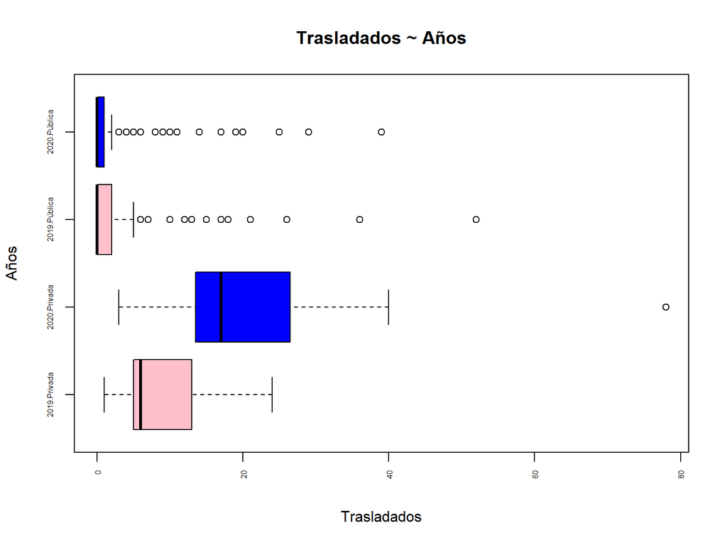

```r
boxplot(DFX$trasladados ~ DFX$Año:DFX$tipo, horizontal = TRUE, las = 3, main = "Trasladados ~ Años", ylab="Años", xlab = "Trasladados",cex.axis=0.5,col= c("pink","blue"))
```

Esta gráfica muestra las medianas de los trasladados de los colegios públicos y privados de los años 2019 y 2020.

```r
summary(DFX$trasladados[DFX$Año=="2019"& DFX$tipo=="Pública"])
```

```
##    Min. 1st Qu.  Median    Mean 3rd Qu.    Max.
##   0.000   0.000   0.000   2.261   2.000  52.000
```

En el 2019 los colegios de tipo “Pública” tienen una media de 2.261 y una mediana de 0. Además podemos decir que un 75% los colegios públicos en el año 2019 tuvieron un total de trasladados de 2 o menos y un 25% de ellos tiene un total de trasladados de 0.

```r
summary(DFX$trasladados[DFX$Año=="2019"& DFX$tipo=="Privada"])
```

```
##    Min. 1st Qu.  Median    Mean 3rd Qu.    Max.
##   1.000   5.000   6.000   9.545  13.000  24.000
```

En el 2019 los colegios de tipo “Privada” tienen una media de 9.545 y una mediana de 6. Además podemos decir que un 75% los colegios privados en el año 2019 tuvieron un total de trasladados de 13 o menos y un 25% de ellos tiene un total de trasladados de 5 o menos.

```r
summary(DFX$trasladados[DFX$Año=="2020"& DFX$tipo=="Privada"])
```

```
##    Min. 1st Qu.  Median    Mean 3rd Qu.    Max.
##    3.00   13.50   17.00   23.27   26.50   78.00
```

En el 2020 los colegios de tipo “Privada” tienen una media de 23.27 y una mediana de 17. Además podemos decir que un 75% los colegios privados en el año 2020 tuvieron un total de trasladados de 26.5 o menos y un 25% de ellos tiene un total de trasladados de 13.5 o menos.

```r
summary(DFX$trasladados[DFX$Año=="2020"& DFX$tipo=="Pública"])
```

```
##    Min. 1st Qu.  Median    Mean 3rd Qu.    Max.
##   0.000   0.000   0.000   1.787   1.000  39.000
```

En el 2020 los colegios de tipo “Pública” tienen una media de 1.787 y una mediana de 0. Además podemos decir que un 75% los colegios públicos en el año 2020 tuvieron un total de trasladados de 1 o menos y un 25% de ellos tiene un total de trasladados de 0.

# Gráfica de Aprobados y años

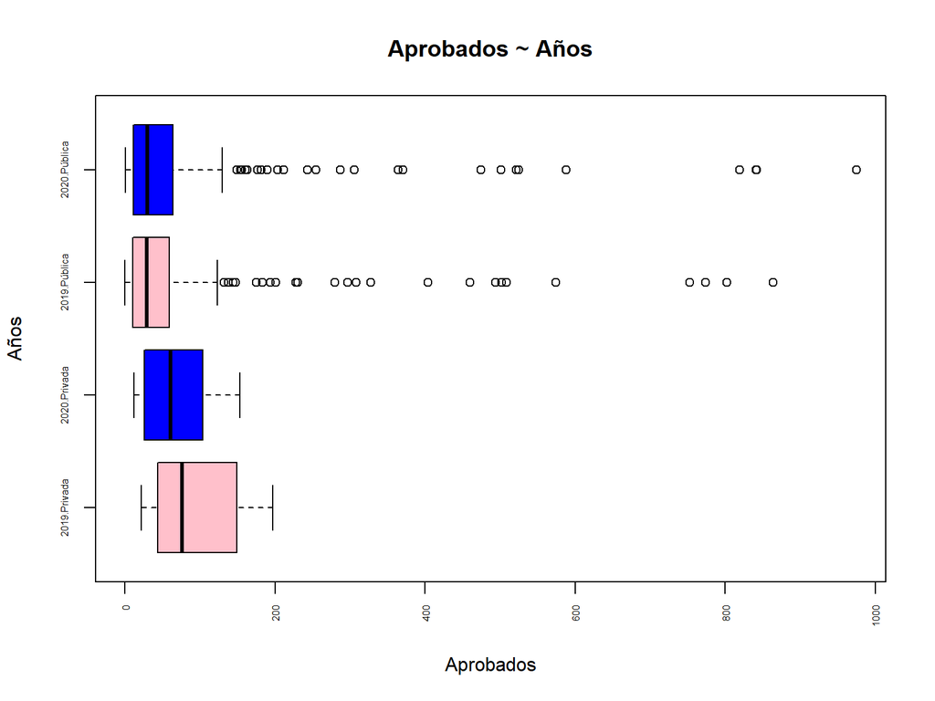

```r
boxplot(DFX$aprobados ~ DFX$Año:DFX$tipo, horizontal = TRUE, las = 3,main = "Aprobados ~ Años", ylab="Años", xlab = "Aprobados", cex.axis=0.5,col= c("pink","blue"))
```

En el gráfico podemos observar que en el eje “x” se encuentra nuestra variable ¨aprobados¨, y en el eje “y” están los tipos de colegio (Privadas y Públicas), por años. En el año 2019 hubo un máximo de 200 niños aprobados, mientras que en el 2020 el número máximo de aprobados, al igual que la mediana, disminuyeron a comparación del año 2019. Además,en los colegios públicos la mediana se ha mantenido.

```r
summary(DFX$aprobados[DFX$Año=="2019"& DFX$tipo=="Pública"])
```

```
##    Min. 1st Qu.  Median    Mean 3rd Qu.    Max.
##    0.00   10.50   29.00   72.47   59.00  864.00
```

En el 2019 los colegios de tipo “Pública” tienen una media de 72.47 y una mediana de 29. Además podemos decir que un 75% los colegios públicos en el año 2019 tuvieron un total de aprobados de 59 o menos y un 25% de ellos tiene un total de aprobados de 10.5 o menos.

```r
summary(DFX$aprobados[DFX$Año=="2019"& DFX$tipo=="Privada"])
```

```
##    Min. 1st Qu.  Median    Mean 3rd Qu.    Max.
##   22.00   44.00   76.00   92.64  149.50  197.00
```

En el 2019 los colegios de tipo “Privada” tienen una media de 92.64 y una mediana de 76. Además podemos decir que un 75% los colegios privados en el año 2019 tuvieron un total de aprobados de 149.5 o menos y un 25% de ellos tiene un total de aprobados de 44 o menos.

```r
summary(DFX$aprobados[DFX$Año=="2020"& DFX$tipo=="Privada"])
```

```
##    Min. 1st Qu.  Median    Mean 3rd Qu.    Max.
##   12.00   26.00   61.00   69.55  104.00  153.00
```

En el 2020 los colegios de tipo “Privada” tienen una media de 69.55 y una mediana de 61. Además podemos decir que un 75% los colegios privados en el año 2020 tuvieron un total de aprobados de 104 o menos y un 25% de ellos tiene un total de aprobados de 26 o menos.

```r
summary(DFX$aprobados[DFX$Año=="2020"& DFX$tipo=="Pública"])
```

```
##    Min. 1st Qu.  Median    Mean 3rd Qu.    Max.
##    1.00   11.50   30.00   78.79   64.00  975.00
```

En el 2020 los colegios de tipo “Pública” tienen una media de 78.79 y una mediana de 30. Además podemos decir que un 75% los colegios públicos en el año 2020 tuvieron un total de aprobados de 64 o menos y un 25% de ellos tiene un total de aprobados de 11.5 o menos.

# Gráfica de Matriculados y años

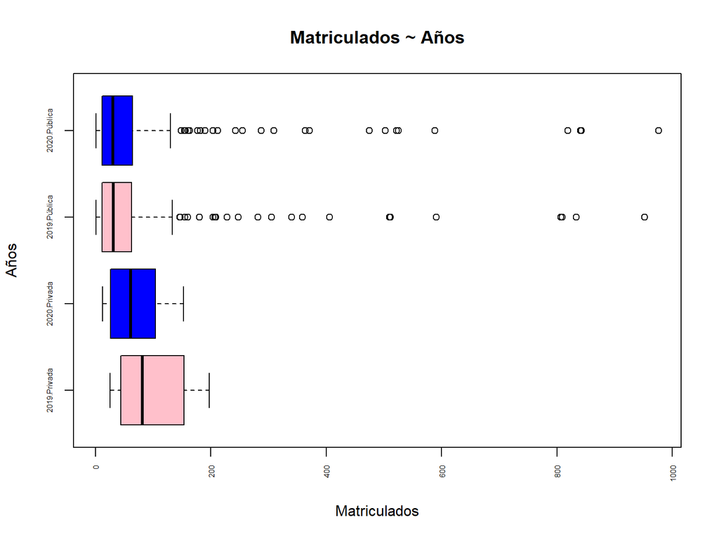

```r
boxplot(DFX$matriculados ~ DFX$Año:DFX$tipo, horizontal = TRUE, las = 3,main = "Matriculados ~ Años", ylab="Años", xlab = "Matriculados", cex.axis=0.5,col= c("pink","blue"))
```

```r
summary(DFX$matriculados[DFX$Año=="2019"& DFX$tipo=="Pública"])
```

```
##    Min. 1st Qu.  Median    Mean 3rd Qu.    Max.
##    1.00   11.50   31.00   76.28   62.50  952.00
```

En el 2019 los colegios de tipo “Pública” tienen una media de 76.28 y una mediana de 31. Además podemos decir que un 75% los colegios públicos en el año 2019 tuvieron un total de matriculados de 62.5 o menos y un 25% de ellos tiene un total de matriculados de 11.5 o menos.

```r
summary(DFX$matriculados[DFX$Año=="2019"& DFX$tipo=="Privada"])
```

```
##    Min. 1st Qu.  Median    Mean 3rd Qu.    Max.
##   25.00   44.00   81.00   96.91  153.50  197.00
```

En el 2019 los colegios de tipo “Privada” tienen una media de 96.91 y una mediana de 81. Además podemos decir que un 75% los colegios privados en el año 2019 tuvieron un total de matriculados de 153.5 o menos y un 25% de ellos tiene un total de matriculados de 44 o menos.

```r
summary(DFX$matriculados[DFX$Año=="2020"& DFX$tipo=="Privada"])
```

```
##    Min. 1st Qu.  Median    Mean 3rd Qu.    Max.
##   12.00   26.00   61.00   69.55  104.00  153.00
```

En el 2020 los colegios de tipo “Privada” tienen una media de 69.55 y una mediana de 61. Ademas podemos decir que un 75% los colegios privados en el año 2020 tuvieron un total de matriculados de 104 o menos y un 25% de ellos tiene un total de matriculados de 26 o menos.

```r
summary(DFX$matriculados[DFX$Año=="2020"& DFX$tipo=="Pública"])
```

```
##    Min. 1st Qu.  Median    Mean 3rd Qu.    Max.
##    1.00   11.50   30.00   78.82   64.00  976.00
```

En el 2020 los colegios de tipo “Publica” tienen una media de 78.82 y una mediana de 30. Además podemos decir que un 75% los colegios públicos en el año 2020 tuvieron un total de matriculados de 64 o menos y un 25% de ellos tiene un total de matriculados de 11.5 o menos.

# Relacionando variables de interés

Nuestras variables de interés son el número de matriculados de ambos tipos de colegio en los años 2019 y 2020.

-Nuevas variables:

AN: Diferencia de matriculados en los colegios entre los años 2020 y 2019

AN1: Diferencia de matriculados en los colegios privados entre los años 2020 y 2019

AN2: Diferencia de matriculados en los colegios públicos entre los años 2020 y 2019

**Diferencia de matriculados en los colegios entre los años 2020 y 2019**

Aquí se puede apreciar la media de lae diferencia del número de matriculados de los diferentes colegios entre los años 2020 y 2019.

```r
AN<-c(DFX$matriculados[DFX$Año=="2020"]-DFX$matriculados[DFX$Año=="2019"])
mAN <- mean(AN)
mAN  ##media de AN
```

```
## [1] 1.03211
```

**Diferencia de matriculados en los colegios privados entre los años 2020 y 2019**

Aquí se puede apreciar la diferencia del número de matriculados de los colegios privados entre los años 2020 y 2019.

```r
AN1<-c(DFX$matriculados[DFX$Año=="2020"& DFX$tipo=="Privada"]-DFX$matriculados[DFX$Año=="2019"& DFX$tipo=="Privada"])
AN1
```

```
##  [1]  12 -15 -53   4 -19 -46 -20 -44 -62   7 -65
```

```r
mAN1 <- mean(AN1)
mAN1  ##media de AN1
```

```
## [1] -27.36364
```

Los números negativos significan que en ese colegio hubieron menos matriculados a comparación del año pasado, mientras que los positivos significan que hubo un aumento de matriculados. En este caso, de los 11 colegios, 8 tuvieron menor número de matriculados y 3 tuvieron un aumento de matriculados.

Claramente se puede observar que en el caso de los colegios privados, hubo una disminución de matriculados en el 2020 a comparación del 2019.

**Diferencia de matriculados en los colegios públicos entre los años 2020 y 2019**

Aquí se puede apreciar la diferencia del número de matriculados de los colegios públicos entre los años 2020 y 2019.

```r
AN2<-c(DFX$matriculados[DFX$Año=="2020"& DFX$tipo=="Pública"]-DFX$matriculados[DFX$Año=="2019"& DFX$tipo=="Pública"])

mAN2 <- mean(AN2)
mAN2 ##media de AN2
```

```
## [1] 2.541063
```

En este caso, de los 207 colegios, 69 tuvieron menor número de matriculados , 110 tuvieron un aumento de matriculados, y 28 no tuvieron ni un aumento ni una disminución de matriculados.

# ESTADÍSTICA INFERENCIAL

# Prueba de hipótesis

Gracias a los resultados obtenidos al calcular la diferencia de matriculados entre los años 2020 y 2019, nació la idea de realizar la prueba de hipótesis a la media en los 3 diferentes casos ya calculados sobre las diferencias de matriculados, y hallar la relación que guarda el total de matriculados en el 2020 y el total de matriculados en el 2019.

Ho: hipótesis nula

H1: hipótesis alternativa

# Prueba de hipótesis 1

```r
t.test (AN)
```

```
##
##  One Sample t-test
##
## data:  AN
## t = 1.1993, df = 217, p-value = 0.2317
## alternative hypothesis: true mean is not equal to 0
## 95 percent confidence interval:
##  -0.6640567  2.7282769
## sample estimates:
## mean of x
##   1.03211
```

En la prueba de hipótesis 1 se obtuvo un p-value mayor a 0.05, debido a esto no podemos rechazar la hipótesis nula. Por lo tanto el promedio real es igual a 0.

# Prueba de hipótesis 2

```r
t.test(AN1, alternative = "less")
```

```
##
##  One Sample t-test
##
## data:  AN1
## t = -3.2313, df = 10, p-value = 0.004501
## alternative hypothesis: true mean is less than 0
## 95 percent confidence interval:
##       -Inf -12.01496
## sample estimates:
## mean of x
## -27.36364
```

En la prueba de hipótesis 2 se obtuvo un p-value menor a 0.05, debido e esto podemos rechazar la hipótesis nula. Al ser nuestra hipótesis alternativa “true mean is less than 0” se concluye que el promedio real sería menor a cero, es decir, el promedio es negativo. Lo que en base a nuestro estudio significaría que en el año 2020 en colegios privados hubo menos matriculado que en 2019.

# Prueba de hipótesis 3

```r
t.test(AN2, alternative = "greater")
```

```
##
##  One Sample t-test
##
## data:  AN2
## t = 3.9324, df = 206, p-value = 5.744e-05
## alternative hypothesis: true mean is greater than 0
## 95 percent confidence interval:
##  1.473381      Inf
## sample estimates:
## mean of x
##  2.541063
```

En la prueba de hipótesis 3 se obtuvo un p-value menor a 0.05, debido a esto podemos rechazar la hipótesis nula. Al ser nuestra hipótesis alternativa “true mean is greater than 0” se concluye que el promedio real sería mayor a cero, es decir, el promedio es positivo. Lo que en base a nuestro estudio significaría que en el año 2020 en colegios públicos hubo más matriculado que en 2019.

# Regresión

### Regresión 1

Se quiere hallar la relación que guarda el total de matriculados en el año 2019 y el total de matriculados en el año 2020 de los colegios privados, usando un nivel de confianza del 95%.

- Variable de correlación

```r
m19i <- (DFX$matriculados[DFX$Año=="2019"& DFX$tipo=="Privada"])
m20i <-(DFX$matriculados[DFX$Año=="2020"& DFX$tipo=="Privada"])
cor(m19i,m20i)
```

```
## [1] 0.9192155
```

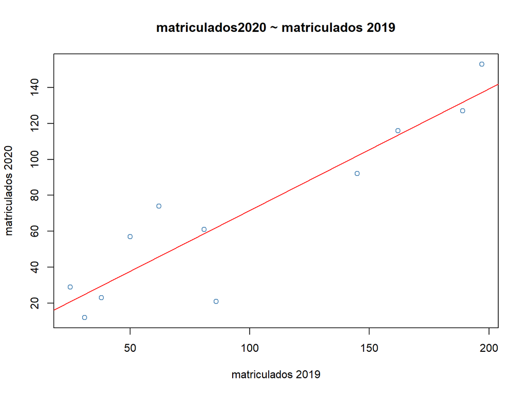

```r
R2 <- lm(m20i~m19i)
plot(m19i, m20i, main = "matriculados2020 ~ matriculados 2019", xlab="matriculados 2019", ylab = "matriculados 2020", col = "steelblue")

abline(R2$coefficients[1], R2$coefficients[2], col = "red")
```

**Resumen de datos**

```r
summary(R2)
```

```
##
## Call:
## lm(formula = m20i ~ m19i)
##
## Residuals:
##     Min      1Q  Median      3Q     Max
## -41.165  -8.386   2.218  11.921  28.072
##
## Coefficients:
##             Estimate Std. Error t value Pr(>|t|)
## (Intercept)   3.9818    11.0960   0.359    0.728
## m19i          0.6765     0.0966   7.003  6.3e-05 ***
## ---
## Signif. codes:  0 '***' 0.001 '**' 0.01 '*' 0.05 '.' 0.1 ' ' 1
##
## Residual standard error: 19.76 on 9 degrees of freedom
## Multiple R-squared:  0.845,  Adjusted R-squared:  0.8277
## F-statistic: 49.05 on 1 and 9 DF,  p-value: 6.301e-05
```

# Datos obtenidos

- La ecuación obtenida:

y = 0.6765477 x + 3.9818334

- También se puede expresar como:

(matriculados 2020) = 0.6765477(matriculados 2019) + 3.9818334

- Intercepto: 3.9818334
- Pendiente: m = 0.6765477
- Variable de correlación: 0.9192155
- El coeficiente de determinación es: r2 = 0.845

### Análisis de los datos obtenidos

- Ecuación regresión: y = 0.6765477 x + 3.9818334
- Correlación: La correlación es directa debido al signo de la variable de correlación, lo que significa que si una variable aumenta, la otra también lo hará. Así mismo, es una correlación alta, lo que significa que ambas variables están altamente relacionadas.

  Ho: Los matrículados del 2019 no guardan relación con los matriculados del 2020

  p-value = 6.301e-05 ; p-value < α ; α = 0.05

  X = m19i ; Y = m20i
- Ya que el p-value es menor a α, podemos rechazar la Ho y validar el modelo ya que la variable X sí aporta al modelo propuesto.
- Coeficiente de determinación: Cuánto de la variabilidad de Y es predicho por X.

# Diagnóstico del modelo

Representación de los residuos estandarizados frente a los valores ajustados, esto resulta muy útil al llevar a cabo el diagnóstico del modelo.

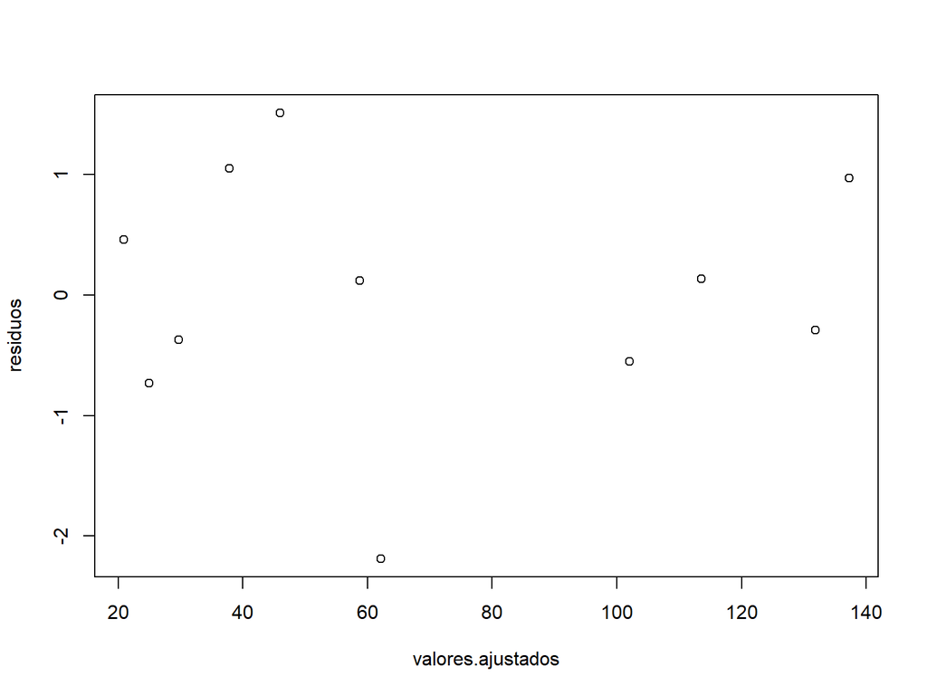

```r
residuos <- rstandard(R2)
valores.ajustados <- fitted(R2)
plot(valores.ajustados, residuos)
```

No se observa ningún patrón especial, por lo que tanto la como la linealidad resultan hipótesis razonables.

Se usa un QQ plot de los residuos para comprobar la hipótesis de normalidad.

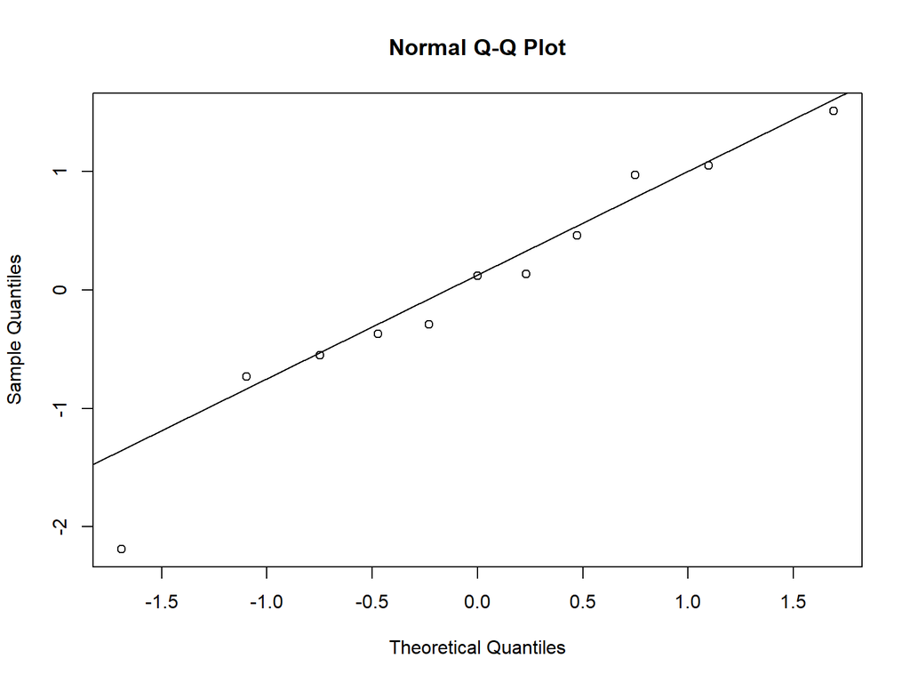

```r
qqnorm(residuos)
qqline(residuos)
```

Dado que los puntos están bastante alineados, la normalidad también parece aceptable.

# Predicción

Supongamos que hubieron 150 matriculados en los colegios privados en el año 2019

- Ecuación: y = 0.6765477 x + 3.9818334

En la ecuación se reemplazará X

```
    x = 150
```

Al resolver la ecuación con el valor de X obtenemos:

```
    y = 0.6765477 (150) + 3.9818334

    y = 105,4639884
```

Entonces, si en el 2019 hubieron 150 matriculados, en el 2020 hubieron 105 matriculados.

# Regresión 2

Se quiere hallar la relación que guarda el número de retirados en el año 2019 y el número de matriculados en el año 2020, usando un nivel de confianza del 95%.

- Variable de correlación

```r
cor(DFX$retirados[DFX$Año=="2019"],DFX$matriculados[DFX$Año=="2020"])
```

```
## [1] 0.08260092
```

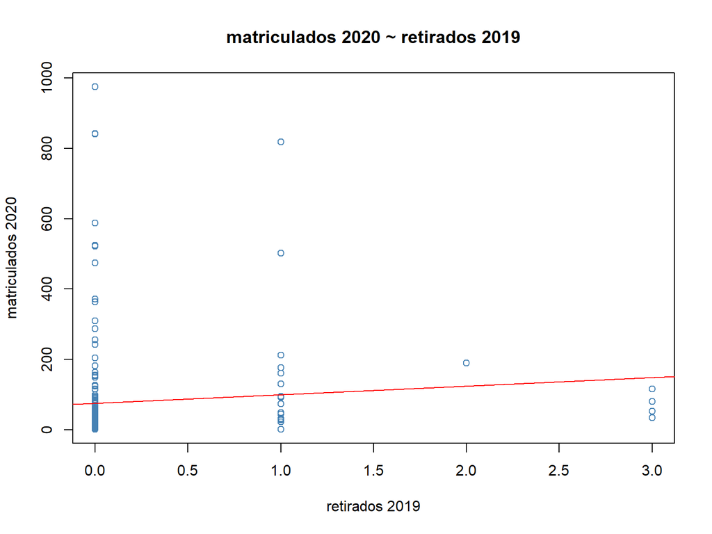

```r
R2 <- lm(DFX$matriculados[DFX$Año=="2020"]~DFX$retirados[DFX$Año=="2019"])
plot(DFX$retirados[DFX$Año=="2019"],DFX$matriculados[DFX$Año=="2020"], main = "matriculados 2020 ~ retirados 2019", xlab="retirados 2019", ylab = "matriculados 2020", col = "steelblue")

abline(R2$coefficients[1], R2$coefficients[2], col = "red")
```

**Resumen de datos**

```r
summary(R2)
```

```
##
## Call:
## lm(formula = DFX$matriculados[DFX$Año == "2020"] ~ DFX$retirados[DFX$Año ==
##     "2019"])
##
## Residuals:
##     Min      1Q  Median      3Q     Max
## -114.67  -64.85  -45.85  -14.10  901.15
##
## Coefficients:
##                                  Estimate Std. Error t value Pr(>|t|)
## (Intercept)                         74.85      10.33   7.247 7.44e-12 ***
## DFX$retirados[DFX$Año == "2019"]    24.61      20.20   1.218    0.224
## ---
## Signif. codes:  0 '***' 0.001 '**' 0.01 '*' 0.05 '.' 0.1 ' ' 1
##
## Residual standard error: 146.5 on 216 degrees of freedom
## Multiple R-squared:  0.006823,   Adjusted R-squared:  0.002225
## F-statistic: 1.484 on 1 and 216 DF,  p-value: 0.2245
```

# Datos obtenidos

- La ecuación obtenida:

y = 24.60558x + 74.85425

- También se puede expresar como:

(matriculados 2020) = 24.60558(retirados 2019) + 74.85425

- Intercepto: 74.85425
- Pendiente: m = 24.60558
- Variable de correlación: 0.08260092
- Coeficiente de determinación: r2 = 0.006823

### Análisis de los datos obtenidos

- Ecuación regresión: y = 24.60558x + 74.85425
- Correlación: La correlación es directa debido al signo de la variable de correlación, lo que significa que si una variable aumenta, la otra también lo hará. Así mismo, es una correlación baja, lo que significa que ambas variables no están muy relacionadas.

  Ho: No hay una relación entre los alumnos que desertaron en 2019 y matriculados en 2020

  p-value = 0.2245 ; p-value > α ; α = 0.05

  X = DFX$retirados[DFX$Año==“2019”] ; Y = DFX$matriculados[DFX$Año==“2020”]
- Ya que el p-value es mayor a α, podemos no rechazar la Ho lo que hace que el modelo sea inválido ya que la variable X no aporta al modelo propuesto.

# Regresión 2.1

Se quiere hallar la relación que guarda el número de retirados y el número de matriculados de los colegios públicos en el año 2020, usando un nivel de confianza del 95%.

- Variable de correlación

```r
r20u <- DFX$retirados[DFX$Año=="2020"& DFX$tipo=="Pública"]
m20u <- DFX$matriculados[DFX$Año=="2020"& DFX$tipo=="Pública"]
cor(r20u,m20u)
```

```
## [1] 0.164078
```

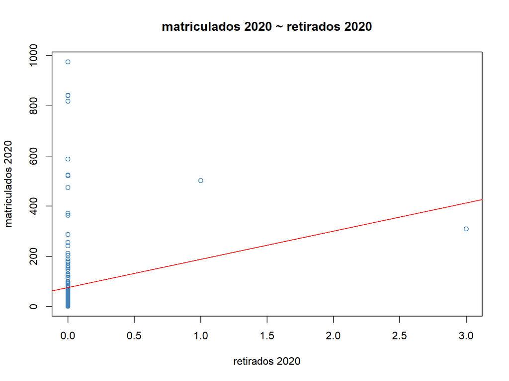

```r
R2 <- lm(m20u~r20u)
plot(r20u,m20u, main = "matriculados 2020 ~ retirados 2020", xlab="retirados 2020", ylab = "matriculados 2020", col = "steelblue")

abline(R2$coefficients[1], R2$coefficients[2], col = "red")
```

**Resumen de datos**

```r
summary(R2)
```

```
##
## Call:
## lm(formula = m20u ~ r20u)
##
## Residuals:
##     Min      1Q  Median      3Q     Max
## -104.37  -66.15  -46.65  -16.65  899.35
##
## Coefficients:
##             Estimate Std. Error t value Pr(>|t|)
## (Intercept)    76.65      10.36   7.400 3.45e-12 ***
## r20u          112.24      47.13   2.382   0.0182 *
## ---
## Signif. codes:  0 '***' 0.001 '**' 0.01 '*' 0.05 '.' 0.1 ' ' 1
##
## Residual standard error: 148.5 on 205 degrees of freedom
## Multiple R-squared:  0.02692,    Adjusted R-squared:  0.02217
## F-statistic: 5.672 on 1 and 205 DF,  p-value: 0.01816
```

# Datos obtenidos

- La ecuación obtenida:

y = 112.23905x + 76.65239

- También se puede expresar como:

(matriculados 2020) = 112.23905(retirados 2020) + 76.65239

- Intercepto: 76.65239
- Pendiente: m = 112.23905
- Variable de correlación: 0.164078
- Coeficiente de determinación: r2 = 0.02692

### Análisis de los datos obtenidos

- y = 112.23905x + 76.65239
- Correlación: La correlación es directa debido al signo de la variable de correlación, lo que significa que si una variable aumenta, la otra también lo hará. Así mismo, es una correlación baja, lo que significa que ambas variables no están muy relacionadas.

  Ho: No hay una relación entre los alumnos que desertaron y los matriculados en el 2020 de los colegios públicos

  p-value = 0.01816 ; p-value < α ; α = 0.05

  X = r20u ; Y = m20u
- Ya que el p-value es menor a α, podemos rechazar la Ho y esto hace que el modelo sea válido ya que la variable X sí aporta al modelo propuesto.
- Coeficiente de determinación ajustado: Cuánto de la variabilidad de Y es predicho por X

Esto nos indica que por más que la variable X sí nos diga algo sobre la variabilidad de la variable Y, pues no lo hace en un porcentaje elevado.

Al analizar los coeficientes de la ecuación obtenemos:

Intercepto = 76.65239 ^ p-value = 3.45e-12

m = 112.23905 ^ p-value = 0.0182

Intercepto:

Ho: Intercepto = 0 ^ H1: Intercepto ≠ 0

Debido a que el p-value es menor a la significancia, podemos rechazar la Ho. Consecuencia de ello, se acepta la hipótesis alternativa H1 la cual nos dice que el intercepto tiene un valor diferente a 0.

- Como el valor del intercepto de nuestro modelo es 76.65239 , podemos concluir que este valor es apropiado para el modelo.

Pendiente(m):

Ho: m=0 ^ H1: m ≠ 0

Debido a que el p-value es menor a la significancia, podemos rechazar la Ho. Consecuencia de ello, se acepta la hipótesis alternativa H1 la cual nos dice que el intercepto tiene un valor diferente a 0.

- Como el valor de la pendiente de nuestro modelo es 112.23905 , podemos concluir que este valor es apropiado para el modelo.

# Conclusiones